# Proposal

## Section 2 - Data

```r
library(tidyverse)
library(openintro)

# Load the data
write.csv(loans_full_schema, "data/loans_data.csv", row.names = FALSE)
loans_data <- read.csv("data/loans_data.csv")
```

```r
glimpse(loans_data)
```

```
## Rows: 10,000
## Columns: 55
## $ emp_title                        <chr> "global config engineer ", "warehouse…
## $ emp_length                       <int> 3, 10, 3, 1, 10, NA, 10, 10, 10, 3, 1…
## $ state                            <chr> "NJ", "HI", "WI", "PA", "CA", "KY", "…
## $ homeownership                    <chr> "MORTGAGE", "RENT", "RENT", "RENT", "…
## $ annual_income                    <dbl> 90000, 40000, 40000, 30000, 35000, 34…
## $ verified_income                  <chr> "Verified", "Not Verified", "Source V…
## $ debt_to_income                   <dbl> 18.01, 5.04, 21.15, 10.16, 57.96, 6.4…
## $ annual_income_joint              <dbl> NA, NA, NA, NA, 57000, NA, 155000, NA…
## $ verification_income_joint        <chr> "", "", "", "", "Verified", "", "Not …
## $ debt_to_income_joint             <dbl> NA, NA, NA, NA, 37.66, NA, 13.12, NA,…
## $ delinq_2y                        <int> 0, 0, 0, 0, 0, 1, 0, 1, 1, 0, 0, 0, 0…
## $ months_since_last_delinq         <int> 38, NA, 28, NA, NA, 3, NA, 19, 18, NA…
## $ earliest_credit_line             <int> 2001, 1996, 2006, 2007, 2008, 1990, 2…
```

[output cut: 42 more lines]

The dataset contains 10000 observations and 55 variables.

## Section 3 - Data Analysis Plan

### Research Question

[What factors contribute the most to a borrowers interest rate?]

### Variables

**Outcome variable (Y):** - `interest_rate` - The interest rate assigned to the loan (continuous, numeric)

**Predictor variables (X):** - `loan_amount` - Amount borrowed (continuous) - `annual_income` - Borrower’s income (continuous) - `grade` - Loan grade (categorical: A, B, C, D, E, F, G) - `term` - Loan term length (categorical: 36 or 60 months)

### Comparison Groups

[We will compare loans with different grades (A vs B vs C, etc.) to see how grade affects interest rate]

### Preliminary Exploratory Data Analysis

```r
# Summary statistics for key variables
loans_data %>%
  select(interest_rate, loan_amount, annual_income) %>%
  summary()
```

```
##  interest_rate    loan_amount    annual_income
##  Min.   : 5.31   Min.   : 1000   Min.   :      0
##  1st Qu.: 9.43   1st Qu.: 8000   1st Qu.:  45000
##  Median :11.98   Median :14500   Median :  65000
##  Mean   :12.43   Mean   :16362   Mean   :  79222
##  3rd Qu.:15.05   3rd Qu.:24000   3rd Qu.:  95000
##  Max.   :30.94   Max.   :40000   Max.   :2300000
```

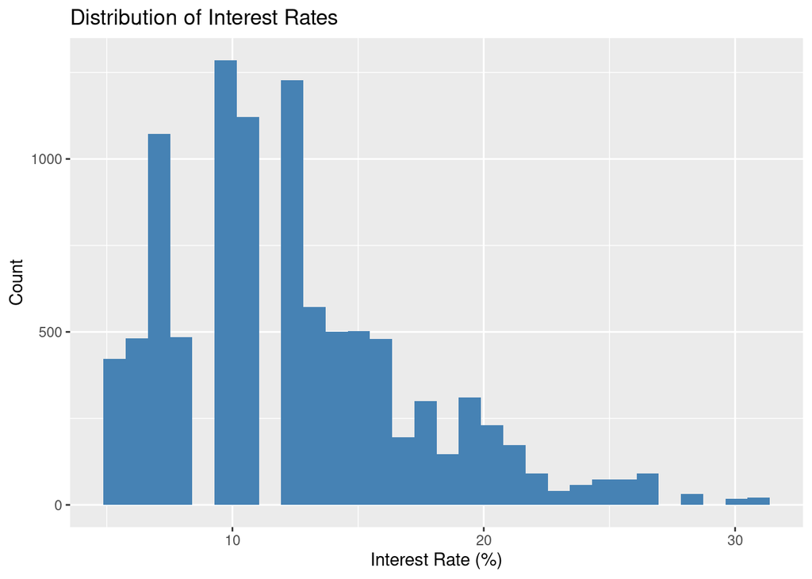

```r
# Distribution of interest rates
ggplot(loans_data, aes(x = interest_rate)) +
  geom_histogram(bins = 30, fill = "steelblue") +
  labs(title = "Distribution of Interest Rates",
       x = "Interest Rate (%)",
       y = "Count")
```

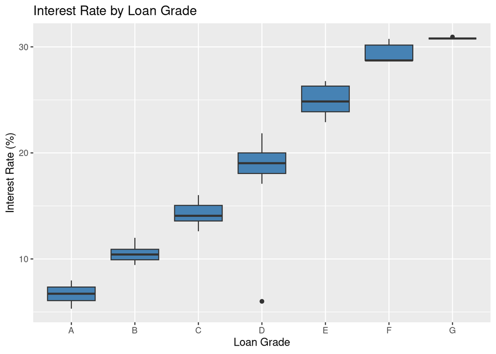

```r
# Relationship between loan grade and interest rate
ggplot(loans_data, aes(x = grade, y = interest_rate)) +
  geom_boxplot(fill = "steelblue") +
  labs(title = "Interest Rate by Loan Grade",
       x = "Loan Grade",
       y = "Interest Rate (%)")
```

**Insights from EDA:** - [There is a clear spread of interest rates, with the highest counts ranging between 5% and 13%] - [Higher loan grades have a linear pattern of lower interests rates compared to lower loan grades]

### Proposed Methods

**Primary method:** Multiple linear regression - Model interest rate as a function of loan amount, income, grade, and term - This will allow us to see which factors most strongly predict interest rates

**Secondary methods:** - ANOVA to compare interest rates across loan grades - Correlation analysis between numeric variables

### Expected Results to Support Hypothesis

To support our hypothesis [Buyers with higher incomes, shorter loan terms, and highers credit scores will have lower average interest rates.], we would need: - Statistically significant coefficients (p < 0.05) for our key predictors - A negative coefficient for annual_income, suggesting higher income leads to lower rates - Significant differences between loan grades in ANOVA test - Model with reasonable R² value indicating good fit